# PRÁCTICA 1A: CÁLCULO DE FRECUENCIAS A NIVEL DE UN CARÁCTER

PROFESOR: DR. LUIS GUILLERMO RUIZ VELÁZQUEZ

ESTUDIANTE: EDGAR SANTIAGO GONZALEZ MARTINEZ

# INTRODUCCIÓN

- **Exportar los archivos desde Google Drive a Colab y cargarlos en el notebook**.
- **Convertir todo a minúsculas y eliminar acentos.**
- **Reemplazar tabulaciones y saltos de línea por espacios simples.**
- **Contar la frecuencia de cada carácter en el conjunto de textos.**
- **Generar un histograma con las frecuencias ordenadas de mayor a menor.**

A continuación se muestran las explicaciones del código, los fragmentos ejecutados y la salida de los resultados paso a paso.

# CONEXIÓN DE GOOGLE DRIVE CON GOOGLE COLAB

Como primer procedimiento, se conecta Google Drive con Google Colab para poder acceder a los archivos almacenados en la nube y utilizarlos en el procesamiento del texto.

La instrucción `from google.colab import drive` permite importar el módulo `drive`, el cual posibilita que Colab interactúe con Google Drive. El comando `drive.mount('/content/drive')` monta Google Drive en la carpeta `/content/drive`. Al ejecutarlo, Colab solicitará un permiso de acceso. Una vez concedido, los archivos estarán disponibles para lectura y escritura dentro del notebook.

**Código:**

```python
# Cargar Google Drive
from google.colab import drive
drive.mount('/content/drive')
```

Abrimos el archivo especificado por `file_path` en modo lectura `("r")` con la codificación `UTF-8` para gestionar caracteres especiales (como acentos y la letra 'ñ'). La estructura with open(...) as f: asegura que el archivo se cierre automáticamente al finalizar, lo que previene errores y el consumo innecesario de recursos.

# TEXTO 1

A continuación, iniciamos el procesamiento del Texto 1, leemos el contenido completo del archivo y lo guardamos en la variable `text` usando `f.read()`. Finalmente, mostramos del carácter 19 al 100 (`text[19:100]`) para verificar que la lectura se realizó correctamente.

```python
# Leer el archivo a nivel de caracteres
file_path = "/content/drive/MyDrive/Maestría MCDI/Manejo y procesamiento de la información/text_1.txt"
with open(file_path, "r", encoding=('utf-8')) as f:
  text = f.read()
text[19:100]
```

```
'Abraham amaba a Sara cada mañana clara: pasaba la manaza, arañaba la lana, arra'
```

A continuación, definimos la función `text_lower_func`, esto convertirá el texto a minúsculas. Esta función recibe un texto (`input_str`) como entrada, aplica el método `.lower()` para transformar todos los caracteres en minúscula y nos regresa el texto modificado.

```python
# Convertir el texto a minúsculas
def text_lower_func(input_str):
    return input_str.lower()

text_lower = text_lower_func(text)
text_lower[19:100]
```

```
'abraham amaba a sara cada mañana clara: pasaba la manaza, arañaba la lana, arra'
```

A continuación, definimos la función `remove_accents`, que se encarga de eliminar los acentos del texto. Para lograr esto, primero normalizamos el texto utilizando la forma NFKD de `unicodedata`, lo que descompone los caracteres acentuados y el acento por separado. Luego, unimos solo los caracteres que no son acentos (según `unicodedata.combining(c)`) para formar una nueva cadena, se guarda en la variable `text_no_accents`.

```python
#texto sin acentos
import unicodedata
def remove_accents(input_str):
    nfkd_form = unicodedata.normalize('NFKD', input_str)
    return u"".join([c for c in nfkd_form if not unicodedata.combining(c)])
text_no_accents = remove_accents(text_lower)
text_no_accents[18:100]
```

```
'abraham amaba a sara cada manana clara: pasaba la manaza, aranaba la lana, arranca'
```

Para eliminar los caracteres especiales, definimos la función `remove_special_chars`. Esta función toma una cadena de texto y recorre una lista predefinida de caracteres (`chars_to_remove`). Usando un bucle `for`, reemplaza cada uno de estos caracteres con una cadena vacía (`""`) en el texto, logrando así su eliminación. Finalmente, la función devuelve el texto ya limpio, sin puntuación ni símbolos, lo que es esencial para el procesamiento de texto.

```python
# Remueve caracteres especiales
def remove_special_chars(input_str):
  chars_to_remove = ";:,.\\-\"'/()[]¿?¡!{}~<>|«»—’"
  cleaned_text = input_str
  for char in chars_to_remove:
    cleaned_text = cleaned_text.replace(char, "")
  return cleaned_text
text_no_special_chars = remove_special_chars(text_no_accents)
text_no_special_chars[18:100]
```

```
'abraham amaba a sara cada manana clara pasaba la manaza aranaba la lana arrancaba '
```

Después definimos la función `replace_newlines`, que elimina los saltos de línea. Esta función toma el texto como entrada y utiliza el método `.replace()` para buscar todos los caracteres de salto de línea (`\n`) y sustituirlos por un espacio en blanco ().

```python
# Reemplazar saltos de línea
def replace_newlines(input_str):
  return input_str.replace('\n', ' ')

text_no_newlines = replace_newlines(text_no_special_chars)
text_no_newlines[18:100]
```

```
'abraham amaba a sara cada manana clara pasaba la manaza aranaba la lana arrancaba '
```

Para reemplazar las tabulaciones, aplicamos el mismo procedimiento. Definimos una función similar, `replace_tabs`, que toma el texto como entrada y usa el método `.replace()` para buscar todos los caracteres de tabulación (`\t`) y sustituirlos por un espacio en blanco ().

```python
# Reemplazar tabulaciones
def replace_tabs(input_str):
  return input_str.replace('\t', ' ')
text_no_tabs = replace_tabs(text_no_newlines)
text_no_tabs[18:100]
```

```
'abraham amaba a sara cada manana clara pasaba la manaza aranaba la lana arrancaba '
```

Para finalizar el proceso de limpieza, simplemente asignamos el texto ya procesado (`text_no_tabs`) a una nueva variable llamada `cleaned_text`. Este paso sirve para tener una variable final con un nombre más descriptivo para el texto limpio. Luego, mostramos una vista previa del carácter 18 al 100 `cleaned_text`, lo que nos permite hacer una última y más extensa verificación del resultado después de aplicar todas las transformaciones.

```python
cleaned_text = text_no_tabs
cleaned_text[18:100]
```

```
'abraham amaba a sara cada manana clara pasaba la manaza aranaba la lana arrancaba '
```

Para calcular la frecuencia de cada carácter en el texto, se define la función `char_freq`. Esta función inicializa un diccionario vacío (`freq`) y luego recorre cada carácter del texto limpio (`cleaned_text`). Por cada carácter, verifica si ya existe en el diccionario; si es así, incrementa su contador en uno; de lo contrario, lo añade con un valor inicial de 1. Finalmente, la función devuelve el diccionario con las frecuencias. Después de obtener las frecuencias se ordena de mayor a menor usando `sorted()` y una función lambda para especificar que se ordene por el valor de la frecuencia (`x[1]`).

El resultado del análisis de frecuencia de los caracteres del texto, mostrando los 10 con más frecuencia. Se obseerva que la letra `'a'` fue el carácter con mayor frecuencia, seguida por el espacio en blanco, que es fundamental para separar las palabras. Le siguen letras como `'l'`, `'r'` y `'s'`, que son muy comunes.

```python
# Frecuencia de caracteres
def char_freq(input_str):
  freq = {}
  for char in input_str:
    if char in freq:
      freq[char] += 1
    else:
      freq[char] = 1
  return freq

freq = char_freq(cleaned_text)

# Ordenar por mayor a menos frecuencia
freq_sorted = sorted(freq.items(), key=lambda x: x[1], reverse=True)
freq_sorted[0:10]
```

```
[('a', 1863),
 (' ', 923),
 ('l', 381),
 ('r', 338),
 ('s', 296),
 ('n', 202),
 ('b', 180),
 ('m', 158),
 ('t', 155),
 ('c', 153)]
```

Para visualizar la frecuencia de los caracteres, utilizamos la biblioteca `matplotlib.pyplot` para crear un histograma. La función `plot_histogram_from_sorted` toma la lista ordenada de frecuencias y la utiliza para crear un gráfico de barras. Dentro de la función, se extraen los caracteres y sus respectivos conteos para ser representados en los ejes X e Y. Se añaden etiquetas a los ejes, un título al gráfico, entre otros complementos.

La gráfica permite ver de forma clara y rápida la distribución de las frecuencias. Cada barra del histograma representa un carácter, y su altura muestra cuántas veces apareció en el texto, lo que ayuda a identificar rápidamente cuáles son los elementos más y menos frecuentes.

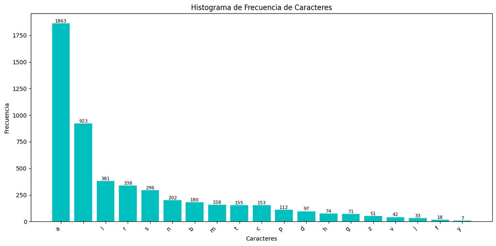

```python
import matplotlib.pyplot as plt

def plot_histogram_from_sorted(freq_sorted):
  # Extrae los caracteres y las frecuencias de la lista ordenada
  chars = [item[0] for item in freq_sorted]
  counts = [item[1] for item in freq_sorted]

  # Crea el histograma
  plt.figure(figsize=(12, 6))
  bars = plt.bar(chars, counts, color='#00BFBF')

  # Agrega etiquetas de datos a cada barra
  for bar in bars:
    yval = bar.get_height()
    plt.text(bar.get_x() + bar.get_width()/2.0, yval + 0.5, int(yval), va='bottom', ha='center', fontsize=8)

  plt.xlabel("Caracteres")
  plt.ylabel("Frecuencia")
  plt.title("Histograma de Frecuencia de Caracteres")
  plt.xticks(rotation=45, ha='right')
  plt.tight_layout()
  plt.show()
plot_histogram_from_sorted(freq_sorted)
```

# TEXTO 2

Tomando en cuenta que ya contamos con todas las funciones de limpieza y análisis previamente definidas, procedemos a aplicarlas de manera secuencial al **texto 2**. Esto nos permite optimizar el flujo de trabajo y evitar la repetición de pasos, logrando que el documento sea más claro y conciso. El proceso incluye convertir todo el contenido a minúsculas, eliminar acentos, reemplazar saltos de línea y tabulaciones, y finalmente suprimir caracteres especiales. Una vez limpio, calculamos la frecuencia de cada carácter y ordenamos los resultados de mayor a menor.

El histograma resultante revela que la letra **"e"** es la más frecuente, con **1360** apariciones, seguida por el **"espacio"** con **674**. Entre las consonantes más comunes destacan la **"r"**, **"s"** y **"n"**, mientras que letras como **"y"** y **"k"** aparecen en muy pocas ocasiones, reflejando su baja frecuencia natural.

```
Histograma para text_2:
```

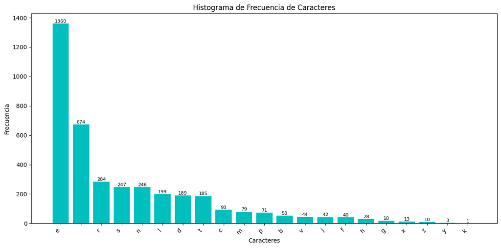

```python
# 1. Leer el nuevo archivo de texto
file_path_2 = "/content/drive/MyDrive/Maestría MCDI/Manejo y procesamiento de la información/text_2.txt"
with open(file_path_2, "r", encoding=('utf-8')) as f:
  text_2 = f.read()

# 2. Aplicar las funciones de limpieza de forma secuencial
cleaned_text_2 = text_lower_func(text_2)
cleaned_text_2 = remove_accents(cleaned_text_2)
cleaned_text_2 = replace_newlines(cleaned_text_2)
cleaned_text_2 = replace_tabs(cleaned_text_2)
cleaned_text_2 = remove_special_chars(cleaned_text_2)

# 3. Calcular la frecuencia de caracteres en el texto limpio
freq_2 = char_freq(cleaned_text_2)
# 4. Ordenar los resultados
freq_sorted_2 = sorted(freq_2.items(), key=lambda x: x[1], reverse=True)

# 5. Generar el histograma
print("Histograma para text_2:")
plot_histogram_from_sorted(freq_sorted_2)
```

# TEXTO 3

Al igual que el texto anterior, se tomaron las funciones ya estructuras y el resultados es el siguiente

El histograma resultante revela que la letra **"i"** es la más frecuente, con **485** apariciones, seguida por la **"espacio"** con **365**. Entre los carácteres más comunes destacan la **"s"**, **"n"** y **"c"**, mientras que letras como **"z"** y **"k"** aparecen en muy pocas ocasiones, reflejando su baja frecuencia natural.

```
Histograma para text_3:
```

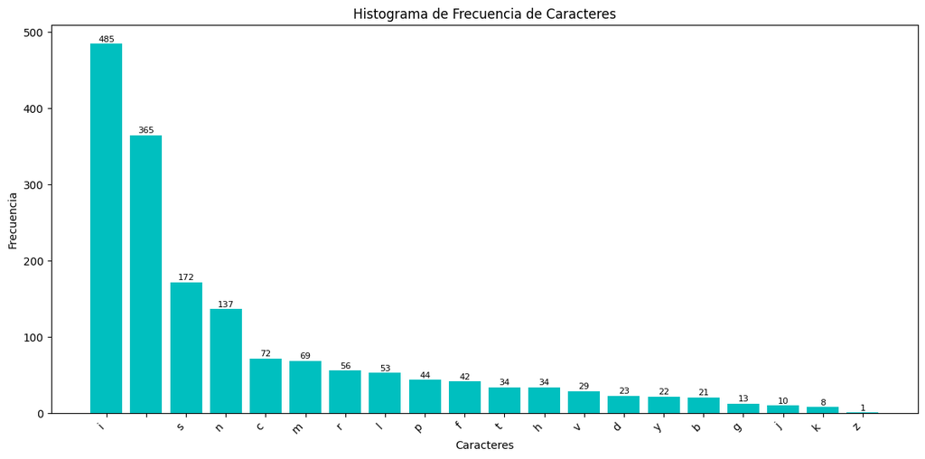

```python
# 1. Leer el nuevo archivo de texto
file_path_3 = "/content/drive/MyDrive/Maestría MCDI/Manejo y procesamiento de la información/text_3.txt"
with open(file_path_3, "r", encoding='utf-8') as f:
    text_3 = f.read()

# 2. Aplicar las funciones de limpieza de forma secuencial
cleaned_text_3 = text_lower_func(text_3)
cleaned_text_3 = remove_accents(cleaned_text_3)
cleaned_text_3 = replace_newlines(cleaned_text_3)
cleaned_text_3 = replace_tabs(cleaned_text_3)
cleaned_text_3 = remove_special_chars(cleaned_text_3)

# 3. Calcular la frecuencia de caracteres en el texto limpio
freq_3 = char_freq(cleaned_text_3)

# 4. Ordenar los resultados
freq_sorted_3 = sorted(freq_3.items(), key=lambda x: x[1], reverse=True)

# 5. Generar el histograma
print("Histograma para text_3:")
plot_histogram_from_sorted(freq_sorted_3)
```

# TEXTO 4

```
Histograma para text_4:
```

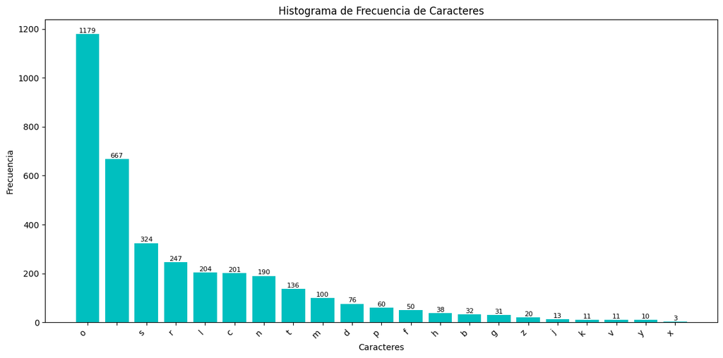

```python
# 1. Leer el nuevo archivo de texto
file_path_4 = "/content/drive/MyDrive/Maestría MCDI/Manejo y procesamiento de la información/text_4.txt"
with open(file_path_4, "r", encoding='utf-8') as f:
    text_4 = f.read()

# 2. Aplicar las funciones de limpieza de forma secuencial
cleaned_text_4 = text_lower_func(text_4)
cleaned_text_4 = remove_accents(cleaned_text_4)
cleaned_text_4 = replace_newlines(cleaned_text_4)
cleaned_text_4 = replace_tabs(cleaned_text_4)
cleaned_text_4 = remove_special_chars(cleaned_text_4)

# 3. Calcular la frecuencia de caracteres en el texto limpio
freq_4 = char_freq(cleaned_text_4)

# 4. Ordenar los resultados
freq_sorted_4 = sorted(freq_4.items(), key=lambda x: x[1], reverse=True)

# 5. Generar el histograma
print("Histograma para text_4:")
plot_histogram_from_sorted(freq_sorted_4)
```

# TEXTO 5

El histograma resultante revela que la letra **"u"** es la más frecuente, con **555** apariciones, seguida por la **"espacio"** con **310**. Entre los carácteres más comunes destacan la **"s"**, **"r"** e **"n"**, mientras que letras como **"a"** y **"o"** aparecen en muy pocas ocasiones, reflejando su baja frecuencia natural.

```
Histograma para text_5:
```

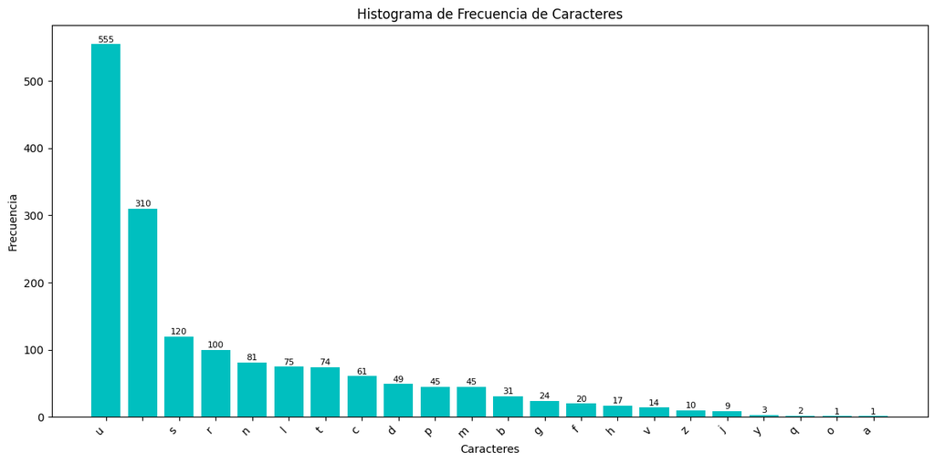

```python
# 1. Leer el nuevo archivo de texto
file_path_5 = "/content/drive/MyDrive/Maestría MCDI/Manejo y procesamiento de la información/text_5.txt"
with open(file_path_5, "r", encoding='utf-8') as f:
    text_5 = f.read()

# 2. Aplicar las funciones de limpieza de forma secuencial
cleaned_text_5 = text_lower_func(text_5)
cleaned_text_5 = remove_accents(cleaned_text_5)
cleaned_text_5 = replace_newlines(cleaned_text_5)
cleaned_text_5 = replace_tabs(cleaned_text_5)
cleaned_text_5 = remove_special_chars(cleaned_text_5)

# 3. Calcular la frecuencia de caracteres en el texto limpio
freq_5 = char_freq(cleaned_text_5)

# 4. Ordenar los resultados
freq_sorted_5 = sorted(freq_5.items(), key=lambda x: x[1], reverse=True)

# 5. Generar el histograma
print("Histograma para text_5:")
plot_histogram_from_sorted(freq_sorted_5)
```

# CONCLUSIONES

Esta práctica abarcó el análisis de texto desde la preparación inicial hasta la visualización de resultados. Comenzamos con la lectura y limpieza del texto, un paso fundamental para estandarizar los datos mediante la conversión a minúsculas, la eliminación de acentos, caracteres especiales, saltos de línea y tabulaciones. Posteriormente, se realizó un análisis de frecuencias para contar y ordenar la aparición de cada carácter. Finalmente, estos datos fueron visualizados mediante un histograma, facilitando una interpretación gráfica y sencilla de la composición a nivel de carácter de los 5 textos.

# REFERENCIAS

Bahit, E. (2012). *Curso Python para principiantes*.

Bird, S., Klein, E., & Loper, E. (2009). *Natural language processing with Python: analyzing text with the natural language toolkit*. O'Reilly Media, Inc.

Hinojosa Gutiérrez, Á. P. (2011). *Introducción al lenguaje de programación de Python*.

**Documento en Colab** [enlace](https://colab.research.google.com/drive/10oQkWFF5yGrD1oQ3XgkV22UyRdHKVXSt?usp=sharing).